# LobsterReport

Anna PerezWelter and Jamie K. Miller

11/14/2018

### 1. Lobster abundance and fishing pressure (2012-2017)

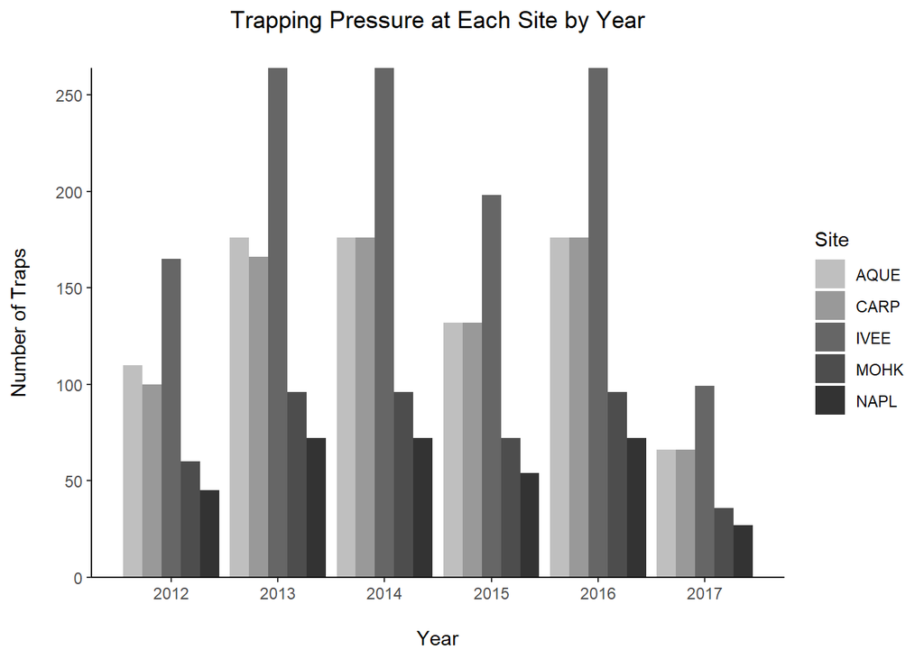

**Figure 1. Lobster trapping pressure at five sites from 2012 to 2017.** Total number of lobster traps at each site (AQUE, CARP, IVEE, MOHK, and NAPL) in Santa Barbara County from 2012 to 2017. Data were collected every two to four weeks from October to March by the Santa Barbara Coastal Long Term Ecological Research Project (SBC LTER).

Relative lobster trapping pressure was consistent each year with the highest trapping pressure at IVEE and the lowest at NAPL for each year (Figure 1). Trapping pressure from all sites increased from 2012 to 2013, then remained constant in 2014. Pressure decreased in 2015 then increased again in 2016. Trapping pressure at all sites greatly decreased to its lowest levels overall in 2017.

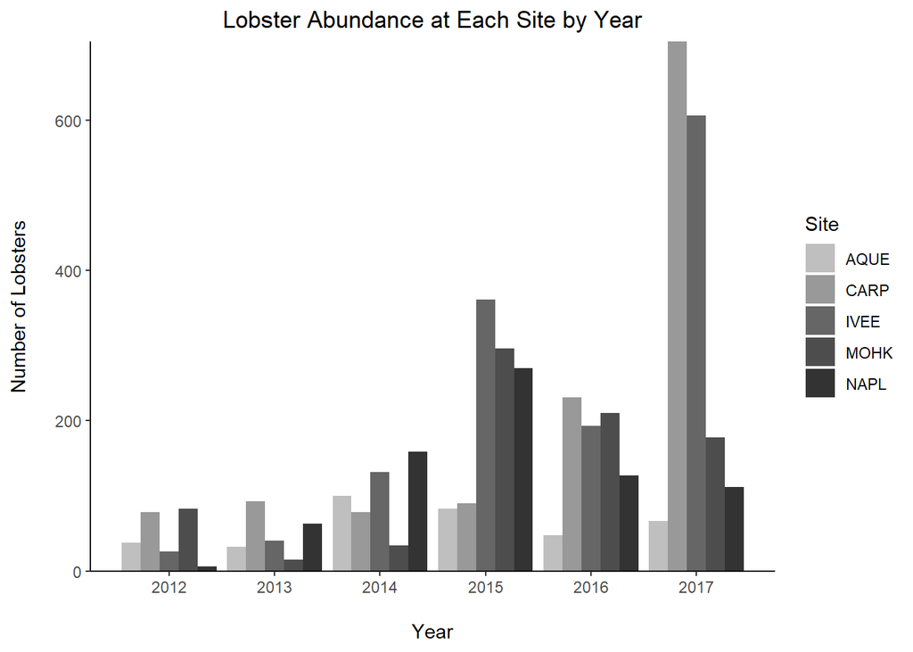

**Figure 2. Lobster abundance at five sites from 2012 to 2017.** Total number of lobsters observed at each site (AQUE, CARP, IVEE, MOHK, and NAPL) in Santa Barbara County from 2012 to 2017. Data were collected every two to four weeks from October to March by the Santa Barbara Coastal Long Term Ecological Research Project (SBC LTER).

Lobster abundance was relatively low from 2012 to 2014 (Figure 2). Abundance increased at IVEE, MOHK, and NAPL in 2015 when trapping pressure decreased. Abundance decreased at all sites except for CARP in 2016. Abundance drastically increased at CARP and IVEE in 2017 while the others remained relatively constant.

### 2. Compare mean lobster size across five sites in 2017

**Table 1. Summarized lobster carapace length at five sites in 2017.** Median, maximum, and mean lobster carapace length (mm) for Santa Barbara County sites (AQUE, CARP, IVEE, MOHK, and NAPL) in 2017 (n = 1668). Data were collected every two to four weeks from October to March by the Santa Barbara Coastal Long Term Ecological Research Project (SBC LTER).

| Site | Lobster Carapace Length (mm) Median | Lobster Carapace Length (mm) Max | Lobster Carapace Length (mm) Mean | Lobster Carapace Length (mm) SD | Lobster Carapace Length (mm) n |
| --- | --- | --- | --- | --- | --- |
| AQUE | 75 | 105 | 73.9 | 11.9 | 67 |
| CARP | 73 | 115 | 72.2 | 13.2 | 705 |
| IVEE | 70 | 150 | 71.5 | 14.3 | 606 |
| MOHK | 71 | 95 | 72.0 | 9.3 | 178 |
| NAPL | 78 | 105 | 76.2 | 11.4 | 112 |

The total number of lobsters observed in 2017 was lowest at AQUE (n = 67) and highest at CARP (n = 705) and IVEE (n = 606) (Table 1).The largest lobster with a carapace length of 150 mm was observed at IVEE. Lobster carapace length significantly differed in at least two sites in 2017 (one-way ANOVA, F(4,1663) = 3.42, $p$ = 0.0085, $\alpha$ = 0.05). Post-hoc analysis with Tukey’s HSD found that lobsters at the NAPL site had the highest mean carapace length of 76.2 +/- 11.4 mm (mean +/- sd, n = 112), and differed significantly from those at CARP (72.2 +/- 13.2 mm (mean +/- sd), n = 705, pairwise p = 0.023) and IVEE (71.5 +/- 14.3 mm (mean +/- sd), n = 606, pairwise p = 0.004) (Figure 3). Carapace length was not significantly different between any of the other sites.

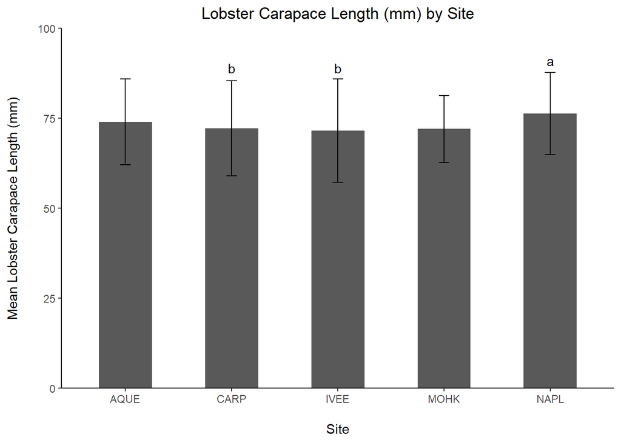

**Figure 3. Lobster carapace length for five sites in 2017.** Mean lobster carapace length (mm) for sites AQUE (n = 67), CARP (n = 705), IVEE (n = 606), MOHK (n = 178), and NAPL (n = 112) in Santa Barbara County in 2017. Error bars indicate +/- 1 standard deviation. Letters indicate that NAPL (a) differed significantly from CARP (b) and IVEE (b) (one-way ANOVA with Tukey’s HSD; F(4,1663) = 3.42, $p$ = 0.0085) with $\alpha$ = 0.05 for all post-hoc pairwise comparisons.

### 3. Change in lobster size at MPA and non-MPA sites between 2012 and 2017

```
## # A tibble: 4 x 7
## # Groups:   MPA [?]
##   MPA      YEAR median   max  mean    sd     n
##   <chr>   <int>  <dbl> <dbl> <dbl> <dbl> <int>
## 1 MPA      2012   64.5   105  67.4  12.2    32
## 2 MPA      2017   72     150  72.2  14     718
## 3 non-MPA  2012   75     156  74.9  12.4   199
## 4 non-MPA  2017   73     115  72.3  12.5   950
```

**Table 2. Summarized lobster carapace length at MPA and non-MPA sites in 2012 and 2017.** Median, maximum, and mean lobster carapace length (mm) for Santa Barbara County MPA (IVEE and NAPL) and non-MPA sites (AQUE, CARP, and MOHK) in 2012 and 2017 (n = 1899). Data were collected every two to four weeks from October to March by the Santa Barbara Coastal Long Term Ecological Research Project (SBC LTER).

| MPA Status | Year | Lobster Carapace Length (mm) Median | Lobster Carapace Length (mm) Max | Lobster Carapace Length (mm) Mean | Lobster Carapace Length (mm) SD | Lobster Carapace Length (mm) n |
| --- | --- | --- | --- | --- | --- | --- |
| MPA | 2012 | 64.5 | 105 | 67.4 | 12.2 | 32 |
| MPA | 2017 | 72.0 | 150 | 72.2 | 14.0 | 718 |
| non-MPA | 2012 | 75.0 | 156 | 74.9 | 12.4 | 199 |
| non-MPA | 2017 | 73.0 | 115 | 72.3 | 12.5 | 950 |

```r
### 3. Change in lobster size at MPA and non-MPA sites between 2012 and 2017
# Hypothesis test

#H0: At MPA sites, there is no difference in carapace size between 2012 and 2017.
#HA: At MPA sites, there is a difference in carapace size between 2012 and 2017.

#H0: At non-MPA sites, there is no difference in carapace size between 2012 and 2017.
#HA: At non-MPA sites, there is a difference in carapace size between 2012 and 2017.


mpa_ttest <- t.test(mpa_size$YEAR, mpa_size$SIZE, conf.level=0.95)
mpa_ttest
```

```
##
##  Welch Two Sample t-test
##
## data:  mpa_size$YEAR and mpa_size$SIZE
## t = 6419.6, df = 1957.2, p-value < 2.2e-16
## alternative hypothesis: true difference in means is not equal to 0
## 95 percent confidence interval:
##  1943.342 1944.530
## sample estimates:
## mean of x mean of y
## 2016.3918   72.4555
```

```r
#  alternative = "greater"
```

```r
#H0: At MPA sites, there is no difference in carapace size between 2012 and 2017.
#HA: At MPA sites, there is a difference in carapace size between 2012 and 2017.

mpa_only <- mpa_size %>%
  filter(MPA == "MPA")

mpa_only_ttest <- t.test(mpa_only$YEAR, mpa_only$SIZE, conf.level=0.95)
mpa_only_ttest
```

```
##
##  Welch Two Sample t-test
##
## data:  mpa_only$YEAR and mpa_only$SIZE
## t = 3805.9, df = 756.86, p-value < 2.2e-16
## alternative hypothesis: true difference in means is not equal to 0
## 95 percent confidence interval:
##  1943.792 1945.798
## sample estimates:
## mean of x mean of y
##  2016.787    71.992
```

```r
#H0: At non-MPA sites, there is no difference in carapace size between 2012 and 2017.
#HA: At non-MPA sites, there is a difference in carapace size between 2012 and 2017.

non_mpa_only <- mpa_size %>%
  filter(MPA == "non-MPA")

non_mpa_only_ttest <- t.test(non_mpa_only$YEAR, non_mpa_only$SIZE, conf.level=0.95)
non_mpa_only_ttest
```

```
##
##  Welch Two Sample t-test
##
## data:  non_mpa_only$YEAR and non_mpa_only$SIZE
## t = 5212.4, df = 1200.7, p-value < 2.2e-16
## alternative hypothesis: true difference in means is not equal to 0
## 95 percent confidence interval:
##  1942.644 1944.107
## sample estimates:
##  mean of x  mean of y
## 2016.13403   72.75805
```

#### Now let’s try this with directionalisty

```r
### Directional ###

### 3. Change in lobster size at MPA and non-MPA sites between 2012 and 2017
# Hypothesis test

#H0: At MPA sites, carapace size is NOT greater in 2017 than 2012.
#HA: At MPA sites, carapace size is greater in 2017 than 2012.

#H0: At non-MPA sites, there is no difference in carapace size between 2012 and 2017.
#HA: At non-MPA sites, there is a difference in carapace size between 2012 and 2017.


mpa_ttest_greater <- t.test(mpa_size$YEAR, mpa_size$SIZE, conf.level=0.95, alternative = "greater")
mpa_ttest_greater
```

```
##
##  Welch Two Sample t-test
##
## data:  mpa_size$YEAR and mpa_size$SIZE
## t = 6419.6, df = 1957.2, p-value < 2.2e-16
## alternative hypothesis: true difference in means is greater than 0
## 95 percent confidence interval:
##  1943.438      Inf
## sample estimates:
## mean of x mean of y
## 2016.3918   72.4555
```

```r
#  alternative = "greater"
```

```r
### Directional ###

#H0: At MPA sites, there is no difference in carapace size between 2012 and 2017.
#HA: At MPA sites, there is a difference in carapace size between 2012 and 2017.

mpa_only_ttest_greater <- t.test(mpa_only$YEAR, mpa_only$SIZE, conf.level=0.95, alternative = "greater")
mpa_only_ttest_greater
```

```
##
##  Welch Two Sample t-test
##
## data:  mpa_only$YEAR and mpa_only$SIZE
## t = 3805.9, df = 756.86, p-value < 2.2e-16
## alternative hypothesis: true difference in means is greater than 0
## 95 percent confidence interval:
##  1943.953      Inf
## sample estimates:
## mean of x mean of y
##  2016.787    71.992
```

```r
### Directional ###

#H0: At non-MPA sites, there is no difference in carapace size between 2012 and 2017.
#HA: At non-MPA sites, there is a difference in carapace size between 2012 and 2017.

non_mpa_only_ttest_greater <- t.test(non_mpa_only$YEAR, non_mpa_only$SIZE, conf.level=0.95)
non_mpa_only_ttest_greater
```

```
##
##  Welch Two Sample t-test
##
## data:  non_mpa_only$YEAR and non_mpa_only$SIZE
## t = 5212.4, df = 1200.7, p-value < 2.2e-16
## alternative hypothesis: true difference in means is not equal to 0
## 95 percent confidence interval:
##  1942.644 1944.107
## sample estimates:
##  mean of x  mean of y
## 2016.13403   72.75805
```

### 4. Proportions of “legal” lobsters at 5 sites in 2017

```r
# Chi Square test

chi_test = chisq.test(lobster_legal_table, simulate.p.value = TRUE)
chi_test
```

```
##
##  Pearson's Chi-squared test with simulated p-value (based on 2000
##  replicates)
##
## data:  lobster_legal_table
## X-squared = 18.497, df = NA, p-value = 0.001499
```

### Conclusions

-What we will likely find is that MPA sites will have larger and more lonsters than non-MPA sites. -Lobster numbers increase after MPAs put in place -as trapping decrease, lobster numbers and sizes increase. -greater proportion of “legal size” lobsters at MPS site. -we’ll need to be careful with these statements because we haven’t done direction tests with some of them yet. We have just shown that there is a significant difference.